# Final Project

### Graphing the Top Ten Words in 2000

```r
Plot2000 <-
ggplot(Graph32000) +
aes(x = reorder(WORD, -FREQ), y = FREQ)+
  geom_bar(fill = "Yellow", stat = "identity", position = "dodge") +
  labs(title = "2000", x = "Word", y = "Count") +
  theme(legend.position = "none")
```

### Filtering the joined table by the year 2010

```r
Graph32010 <-
  FilteredLyrics %>%
  filter(decade == "2010")
```

### Counting the words in the 2010’s

```r
Graph32010 <-
  freq_terms ( Graph32010$word, 10, at.least = 3)
```

### Graphing the Top Ten Words in the 2010’s

```r
Plot2010 <-
ggplot(Graph32010) +
aes(x = reorder(WORD, -FREQ), y = FREQ)+
  geom_bar(fill = "Orange", stat = "identity", position = "dodge") +
  labs(title = "2010", x = "Word", y = "Count") +
  theme(legend.position = "none")
```

### Combining the Individual Decade Graphs

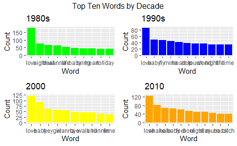

```r
grid.arrange(Plot1980, Plot1990, Plot2000, Plot2010, ncol = 2, top = "Top Ten Words by Decade")
```

### From the above graphs, we can see that love was the most popular song for each decade, which would make sense given that love was the song popular word amongst all decades in Graph 2. As we move away from the top word in each decade, we see that some of the words change in popularity. Decades 1990 and 2010 both have 11 words meaning that some of the words had the same count for these two decades.

### Graph 4

### Joing the Sentiments with the Filtered Lyrics Data Frame

```r
FilteredSentiments <-
  FilteredLyrics %>%
  inner_join(sentiments)
```

### Making the sentiment a 0 or 1

```r
  FilteredSentiments <-
  FilteredSentiments %>%
  mutate(sentiment = ifelse(sentiment =="negative", 0, 1))
```

### Getting the net sentiment

```r
FilteredSentimentsgraph4 <-
  FilteredSentiments %>%
  group_by(year,decade) %>%
  summarise(netsentiment = sum(sentiment)) %>%
  mutate (year = as.numeric(year))
```

### Graph of the net sentiment per year

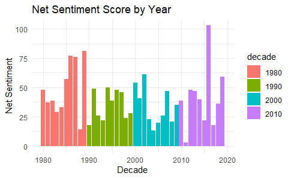

```r
ggplot(FilteredSentimentsgraph4) +
  aes(x =year, y = netsentiment, fill = decade) +
  geom_bar(stat = "identity", position = "dodge")+
  labs(title = "Net Sentiment Score by Year", x = "Decade", y = "Net Sentiment") +
  theme_minimal()
```

### As we can see from the graph above, the net sentiment appears to be close if value per each year in the decades 1990 and 200 while the 2010 and 1980 decades have much more variability in their net sentiment score per year. 2010 has the highest net sentiment as well as minimum net senitment.

### Graph 5

### Getting the mean sentiment per decade

```r
FilteredSentimentsgraph5 <-
  FilteredSentiments %>%
  group_by(decade) %>%
  summarise(mean_sentiment = mean(sentiment))
```

### Graphing the mean sentiment

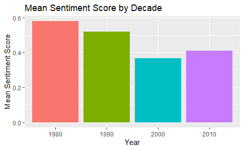

```r
ggplot(FilteredSentimentsgraph5) +
  aes( x = decade, y = mean_sentiment, fill = decade) +
  geom_bar(stat = "identity", position = "dodge") +
  labs(title = "Mean Sentiment Score by Decade", x = "Year", y = "Mean Sentiment Score") +
  theme(legend.position = "none")
```

```r
NA
NA
NA
```

### From the above graph, we can see that the decade 1980 has the highest mean sentiment score of around .575 and the year 2000 has the smallest mean sentiment of around .35. Each bar in the bar graph grouped the sentiments by decade.

### Graph 6

### Getting the net sentiment score for each decade

```r
FilteredSentimentsgraph6 <-
  FilteredSentiments %>%
  group_by(year,decade) %>%
  summarise(netsentiment = sum(sentiment))
```

### Graphing the Net Sentiment Score for each Decade

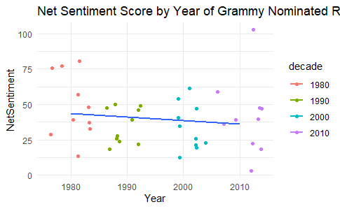

```r
ggplot(FilteredSentimentsgraph6, aes(x = decade, y = netsentiment, colour = decade)) +
  labs(title = "Net Sentiment Score by Year of Grammy Nominated Records from 1980-2019 with Linear Model Fit", x = "Year", y = "NetSentiment") +
  geom_point( stat = "identity" ,position = "jitter", group = 1) +
  geom_smooth (method = lm, na.rm = TRUE, fullrange = TRUE, aes(group = 1), se = FALSE) +
  theme_minimal()
```

```r
NA
NA
```

### From the graph above, we see that there is a negative correlation between the net sentiment and the year, meaning that we cannot conclude that the net sentiment value can be predicted based off a certain year.